# Tutorial on Bayesian Statistics. Homework from BDA3

Fernando Hoces de la Guardia

- 1.1
- 1a: $\begin{aligned} p(y) &= \frac{1}{2} \left( p(y| \theta = 1) + p(y| \theta = 2) \right) \nonumber\\ &= \frac{1}{2} \left( N(y|1,2^{2}) + N(y|2,2^{2}) \right) \end{aligned}$

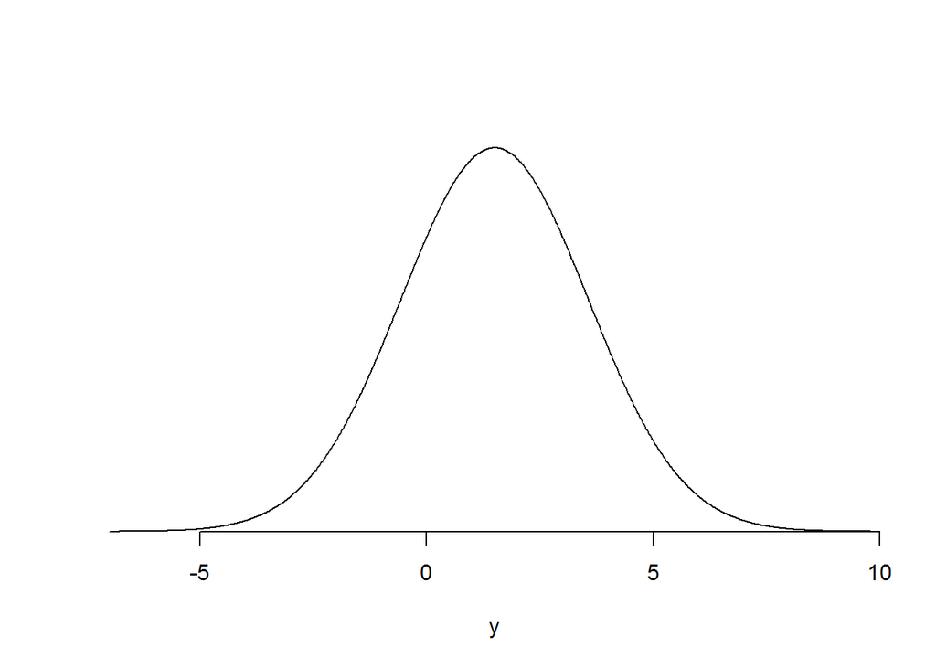

```r
domain          <- seq(-7,10,.02)
dens            <- 0.5*dnorm(domain,1,2) + 0.5*dnorm(domain,2,2)
plot (domain, dens, ylim=c(0,1.1*max(dens)),
type="l", xlab="y", ylab="", xaxs="i",
yaxs="i", yaxt="n", bty="n", cex=2)
```

- 1b: $\begin{aligned} p(\theta = 1 | y = 1 ) &= \frac{p(\theta = 1)p(y = 1| \theta = 1)}{\sum_{i=1}^{2}p(\theta = i)p(y = 1| \theta = i)} \nonumber \\ &= \frac{0.5N(1|1,4)}{\sum_{i=1}^{2}0.5N(1|i,4)} \end{aligned}$

```r
p.theta.1       <- function(sigma) {
  res1          <- (0.5*dnorm(1,1,sigma)) /(sum(0.5*dnorm(1,c(1,2),sigma)))
  return(res1)
  }
```

Evaluating the last expression in the respective cumulative distribution function we get:0.5312094. **Note: even though we are adding “discrete” number of probabilities, we are still in the continuous space (but for $y=1$) and should evaluate the probabilities in the density function.**

- 1c:

**Table 1: Posterior probabilty of $\theta = 1$, af a function of $\sigma$**

| $\sigma$ | $p(\theta = 1 \| y = 1 )$ |
| --- | --- |
| 0.25 | 0.9996646 |
| 0.5 | 0.8807971 |
| 1 | 0.6224593 |
| 2 | 0.5312094 |
| 4 | 0.5078119 |
| 8 | 0.5019531 |

- 1.3  
  First: compute posterior of probability of having $Xx$ genes knowing that parents have brown eyes and individual has brown eyes:

$\begin{aligned} &p(Xx | \text{Person and parents have brown eyes}) = \\ &\frac{ Pr(Xx|(XX,XX))Pr((XX,XX)) + Pr(Xx|(Xx,XX))Pr((Xx,XX)) + Pr(Xx|(Xx,Xx))Pr((Xx,Xx)) } {Pr(Brown|(XX,XX))Pr((XX,XX)) + Pr(Brown|(Xx,XX))Pr((Xx,XX)) + Pr(Brown|(Xx,Xx))Pr((Xx,Xx)) } \nonumber \\ &= \frac{ 0 \cdot (1-p)^{4} + 1/2 \cdot 4p(1-p)^{3} + 1/2 \cdot 4p(1-p)^{2} } { 1 \cdot (1-p)^{4} + 1 \cdot 4p(1-p)^{3} + (1-Pr(Blue|(Xx,Xx))) \cdot 4p(1-p)^{2} } \\ &= \frac{ 0 \cdot (1-p)^{4} + 1/2 \cdot 4p(1-p)^{3} + 1/2 \cdot 4p(1-p)^{2} } { 1 \cdot (1-p)^{4} + 1 \cdot 4p(1-p)^{3} + 3/4 \cdot 4p(1-p)^{2} } \\ &= \frac{2p}{1+2p} \end{aligned}$

This posterior ($p(Xx | \text{Person and parents have brown eyes})$) will be the new prior when computing the probability that Judy’s is $Xx$ given that all her kids are brown eyed (husband is $Xx$). $\begin{aligned} &p(Judy = Xx | \text{all n kids brown eyes (AKBE) + previous info.}) = \nonumber \\ &\frac{P(Judy = Xx) P(AKBE|Judy=Xx) }{P(Judy = Xx) P(AKBE|Judy=Xx) + P(Judy \neq Xx) P(AKBE|Judy \neq Xx)} \\ &= \frac{ \frac{2p}{1+2p} (\frac{3}{4})^{n} }{ \frac{2p}{1+2p} (\frac{3}{4})^{n} + \frac{1}{1+2p} } \end{aligned}$

Now we want to compute the probability that the first grandchildren will have blue eyes. We know that all Judy’s children have brown eyes, hence have genes $Xx$ or $XX$. It follows that the grandkids will have blue eyes only if the kids have $Xx$ genes. A kid will have $Xx$ if Judy has $Xx$ and she and her husband provide $Xx$ ($pr=2/3$, remember that the kid has brown eyes) or if she has $XX$ and her husband provide $Xx$ ($pr=1/2$). Hence the probability of any kid to be $Xx$ is: $\begin{aligned} P(kid = Xx| \text{all info}) &= P(kid = Xx| \text{all info} + Judy = Xx)P(Judy = Xx) + P(kid = Xx| \text{all info} + Judy \neq Xx)P(Judy \neq Xx) \nonumber \\ &= \left( \frac{2}{3} \right) \frac{ \frac{2p}{1+2p} (\frac{3}{4})^{n} }{ \frac{2p}{1+2p} (\frac{3}{4})^{n} + \frac{1}{1+2p} } + \left( \frac{1}{2} \right) \frac{ \frac{1}{1+2p} (\frac{3}{4})^{n} }{ \frac{2p}{1+2p} (\frac{3}{4})^{n} + \frac{1}{1+2p} } \end{aligned}$

Conditional on a kid having $Xx$ the probability of having a grandchild with blue eyes is 0,1/4 and 1/2 if the spouse is $XX$, $Xx$ and $xx$ respectively. Each spouse type has a probability of $(1-p)^{2}, 2p(1-p)$ and $p^2$ respectively. Hence, the probability of a grandkid with blue eyes is: $\begin{aligned} P(Grandchildren = Blue|\text{all info}) &= \frac{ \frac{2}{3}\frac{2p}{1+2p} + \frac{1}{2}\frac{1}{1+2p} }{\frac{2p}{1+2p} (\frac{3}{4})^{n} + \frac{1}{1+2p} } \left( \frac{1}{4}2p(1-p) + \frac{1}{2}p^{2} \right) \\ &= \frac{ \frac{2}{3}\frac{2p}{1+2p} + \frac{1}{2}\frac{1}{1+2p} }{\frac{2p}{1+2p} (\frac{3}{4})^{n} + \frac{1}{1+2p} } \left( \frac{1}{2}p \right) \nonumber \end{aligned}$ Note: Some of the solutions presented here are have been reverse engineered from [here.](http://www.stat.columbia.edu/~gelman/book/solutions3.pdf). A few additional lines were added.

- 1.6 The trick here is that the probability of having a fraternal twin birth with to boys is $1/4 \times 1/125$ and a identical twin birth of boys is $1/2 \times 1/300$. Hence the probability that Elvis had an identical twin is $5/11$.
- 1.7 *Let’s Make a Deal*  
  Calculate the probability of winning for each box after one of the empty boxes has been revealed and is not a winning box.

Lets define the following events:  
* $A:$ The participant chose the right box at the beginning.  
* $B:$ The host opens a particular box, among the unchosen ones, such that is empty.  
* $C:$ Among the unchosen boxes the host chooses a empty box.

And let’s compute the probabilities of each of this events.  
$\begin{aligned} Pr(A) &= 1/3\\ Pr(C) &= 1/2\\ Pr(B) &= Pr(B|A)Pr(A) + Pr(B|\neg A)Pr(\neg A) = (1/2)*(1/3) + Pr(B|\neg A)*(2/3)\\ &= 1/6 + 2/3*(Pr(B|\neg A,C)Pr(C) + Pr(B|\neg A,\neg C)Pr(\neg C)) \\ &= 1/6 + 2/3*(1*(1/2) + 0*(1/2)) = 1/2 \end{aligned}$ Using Bayes’ theorem we have that the probability of choosing the right box from the beginning, conditional on a unchosen box being revealed as a losing one is:

$Pr(A|B) = \frac{Pr(A)Pr(B|A)}{Pr(B)} = \frac{(1/3)*(1/2)}{1/2}=\frac{1}{3}$

The participant’s chances are not equal across remaining boxes! She is worst of staying with her original choice (33% probability of wining instead of 50%!).

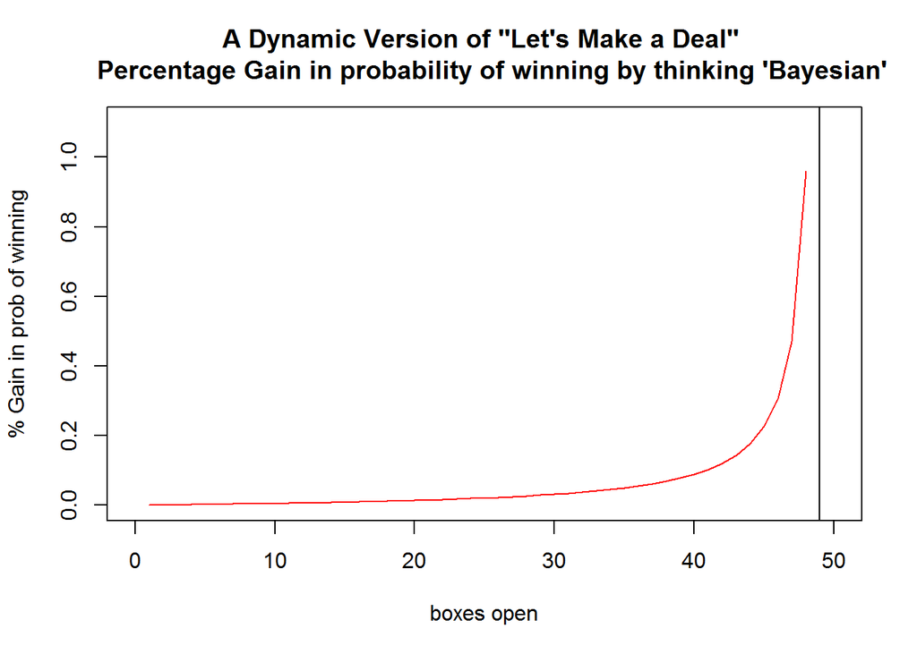

Looking at the graph it seems that the advantages of thinking in a Bayesian fashion are certainly parameter-specific. Also notice that the player here chooses a “stubborn” strategy, I suspect that if she changes boxes in a optimal way the improvement in her chances will be slightly less. Maybe that is the reason why we don’t think in a Bayesian fashion all the time.

Note: Some of the solutions presented here are have been reverse engineered from [here.](http://www.stat.columbia.edu/~gelman/book/solutions3.pdf)

- 2.1 $\begin{aligned} P(\theta) &= Beta(4,4) \\ P( y | \theta) &= Bin(y|n,\theta) \\ \Rightarrow P(\theta|y) &= Beta(4+y,4+(n-y)) \end{aligned}$  
  The **wrong** way to answer the question would be:  
  $\begin{aligned} P(\theta|y<3) &\propto \sum_{i=0}^{2}Beta(4+i,4+(n-i)) \end{aligned}$ The **right** way to answer the question would be:  
  $\begin{aligned} P( y<3 | \theta) &= \sum_{i=0}^{2}Bin(i|n,\theta)\\ \Rightarrow P(\theta|y) &\propto \sum_{i=0}^{2} {n \choose i} Beta(4+i,4+(n-i))\\ \end{aligned}$ In this case some part of the proportionality constant *does* matter.

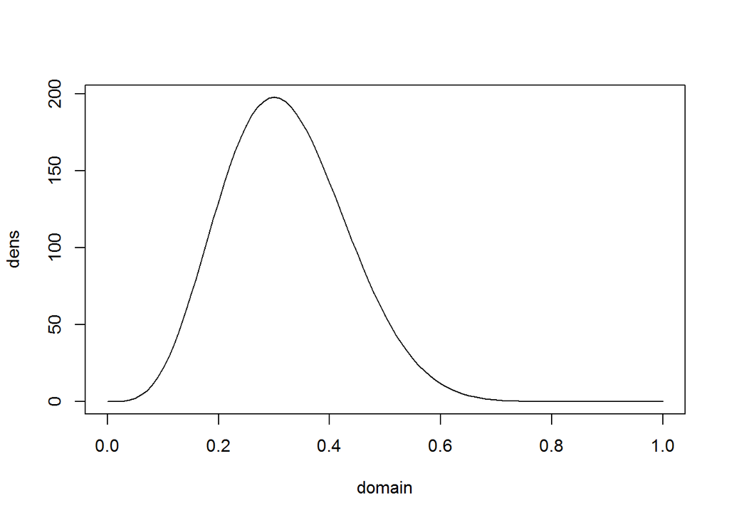

```r
domain <- seq(0,1,.01)
dens = apply(sapply(0:2,function(x) choose(10,x)*dbeta(domain,4+x,4+10-x)),1,sum)
plot(domain, dens, type="l")
```

- 2.14
- 2.14a Deriving the posterior for a normal likelihood with known variance, unknown mean, and using a normal prior. [Slide 15 here](http://www.people.fas.harvard.edu/~plam/teaching/methods/conjugacy/conjugacy_print.pdf)

**Note:** a good reminder of the main conjugacy relationships can be found [here](http://www.johndcook.com/conjugate_prior_diagram.html)

- 2.16a Suppose $y \sim Bin(n,\theta)$, with $\theta \sim Beta(\alpha, \beta)$. Derive marginal distribution of $y$ (unconditional on $\theta$)

$\begin{aligned} P(y = k) &= \int_{O}^{1} p(y,\theta) d\theta \\ &= \int_{O}^{1} p(y|\theta) p(\theta) d\theta \\ &= \int_{O}^{1} {n \choose k} \theta^{k} ( 1 - \theta)^{n-k} \times \frac{\Gamma(\alpha + \beta)}{\Gamma(\alpha)\Gamma(\beta)} \theta^{\alpha - 1} ( 1 - \theta)^{\beta - 1} d\theta \\ &= {n \choose k} \frac{\Gamma(\alpha + \beta)}{\Gamma(\alpha)\Gamma(\beta)} \int_{O}^{1} \theta^{k + \alpha - 1} ( 1 - \theta)^{n - k + \beta - 1} d\theta \\ &= {n \choose k} \frac{\Gamma(\alpha + \beta)}{\Gamma(\alpha)\Gamma(\beta)} \int_{O}^{1} \frac{\Gamma(\alpha + k)\Gamma(\beta + n - k)}{\Gamma(\alpha + \beta + n)} \frac{\Gamma(\alpha + \beta + n)}{\Gamma(\alpha + k)\Gamma(\beta + n - k)} \theta^{k + \alpha - 1} ( 1 - \theta)^{n - k + \beta - 1} d\theta \\ &= {n \choose k} \frac{\Gamma(\alpha + \beta)}{\Gamma(\alpha)\Gamma(\beta)} \frac{\Gamma(\alpha + k)\Gamma(\beta + n - k)}{\Gamma(\alpha + \beta + n)} \int_{O}^{1} \frac{\Gamma(\alpha + \beta + n)}{\Gamma(\alpha + k)\Gamma(\beta + n - k)} \theta^{k + \alpha - 1} ( 1 - \theta)^{n - k + \beta - 1} d\theta \\ &= {n \choose k} \frac{\Gamma(\alpha + \beta)}{\Gamma(\alpha)\Gamma(\beta)} \frac{\Gamma(\alpha + k)\Gamma(\beta + n - k)}{\Gamma(\alpha + \beta + n)} \end{aligned}$

Where the second to last line follows from integrating the density of a $Beta(k + \alpha, n - k + \beta)$

- 2.19 Exponential model with conjugate prior distribution:
  - 2.19a Prove conyugacy for $y_{i}|\theta \sim Exp(\theta)$ for $i= 1, \dots ,n$ , iid, and $\theta \sim Gamma(\alpha, \beta)$:

$\begin{aligned} p(\theta| \mathbf{y}) &\propto p(\mathbf{y}|\theta)p(\theta) \\ &= p(\theta) \prod_{i=1}^{n} p(y_{i}|\theta) \\ &= \frac{\beta^{\alpha}}{\Gamma(\alpha)} \theta^{\alpha - 1} exp(-\beta \theta) \times \prod_{i=1}^{n} \theta exp(-\theta y_{i}) \\ &= \frac{\beta^{\alpha}}{\Gamma(\alpha)} \theta^{\alpha - 1} exp(-\beta \theta) \times \prod_{i=1}^{n} \theta exp(-\theta y_{i}) \\ &= \frac{\beta^{\alpha}}{\Gamma(\alpha)} \times \theta^{\alpha + n - 1} exp(-\theta(\beta + \sum y_{i}) ) \\ &\propto \frac{(\beta + \sum y_{i})^{\alpha + n}}{\Gamma(\alpha + n)} \theta^{\alpha + n - 1} exp(-\theta(\beta + \sum y_{i}) ) \\ &= Gamma(\alpha + n, \beta + \sum y_{i}) \end{aligned}$ - 2.19b Show that the equivalent prior specification for the mean $\phi = 1/\theta$, is inverse-gamma.  
**Solution:** We will use the transformation method. For this purpose we define: $\phi = g(\theta) = 1/\theta$, This implies that $g^{-1}(\phi) = 1/\phi$ and $\frac{d}{d\phi} g^{-1}(\phi) = - 1/\phi^{2}$. Now:

$\begin{aligned} f_{\phi}(\phi) &= f_{\theta}\left( g^{-1}(\phi) \right) |\frac{d}{d\phi}g^{-1}(\phi)|\\ &= \frac{\beta^{\alpha}}{\Gamma(\alpha)} \frac{1}{\phi^{(\alpha - 1)}} exp(-\beta/\phi) \frac{1}{\phi^2} \\ &= \frac{\beta^{\alpha}}{\Gamma(\alpha)} \phi^{- (\alpha + 1)} exp(-\beta/\phi) \\ &= Inv\text{-}Gamma(\phi) \end{aligned}$

- 2.19c The length of life ($y_{i}$) of a ligth bulb is distributed $Exp(\theta)$, with $\theta \sim Gamma(\alpha, \beta)$ and Coefficient of Variation ($\sqrt{Var(\theta)} / E(\theta)$) equal to $0.5$. How many observation do we need to reduce the posterior CV to $0.1$?

$\begin{aligned} CV(\theta) &= \frac{\sqrt{\alpha}/\beta}{\alpha/\beta} = \frac{1}{\sqrt{\alpha}} = 0.5 \implies \alpha = 4 \\ CV(\theta|y) &= \frac{\sqrt{4 + n}/( \beta + \sum y_{i} ) } { (4+n)/(\beta + \sum y_{i})} = \frac{1}{\sqrt{4 + n}} = 0.1\\ \implies n &= 96 \end{aligned}$

- 2.19d How would your answer change if the CV refers to $\phi$ instead of $\theta$? For this excercise we will use the fact that Inverse-Gamma distributions are conjugate with exponentials, where the resulting posterior has parameters $IG(\alpha +n, \beta + \sum y_{i})$. Following the same steps as in (c), but for the mean and variance of the IG, we get $\alpha = 6$. Solving for the CV of the posterior we get $n = 96$.
- 3.7 Show that the likelihood of two indpendent poisson $v \sim Pois(\theta_{v}), b \sim Pois(\theta_{b})$ is the same as the likelihood of a $b|v+b \sim Bin(v+b, \frac{\theta_{b}}{\theta_{b} + \theta_{v}})$. **Solution:** For this proof I follow [Blitztein & Hwang - Ch4 - p166-167](http://www.amazon.com/gp/product/1466575573/ref=pd_lpo_sbs_dp_ss_2?pf_rd_p=1944687522&pf_rd_s=lpo-top-stripe-1&pf_rd_t=201&pf_rd_i=188652940X&pf_rd_m=ATVPDKIKX0DER&pf_rd_r=0Y2GG9RTCM87QYXDVJQJ):
- First, we get the distribution of $y = v + b$ (conditioning by $b$ and using the law of total probability): $\begin{aligned} P(y=k) &= P(v+b=k) = \sum_{j=1}^{k} P(v + b = k|b = j)P(b = j)\\ &= \sum_{j=1}^{k} P(v = k - j)P(b = j)\\ &= \sum_{j=1}^{k} \frac{e^{ -\theta_{v} } \theta_{v}^{k - j} }{(k-j)!} \frac{e^{ -\theta_{b} } \theta_{b}^{j} }{j!}\\ &= \sum_{j=1}^{k} \frac{e^{ -(\theta_{v} + \theta_{b}) } \theta_{v}^{k - j} \theta_{b}^{j} }{(k-j)!j!} \frac{k!}{k!}\\ &= \frac{e^{ -(\theta_{v} + \theta_{b}) } }{k!} \sum_{j=1}^{k} {k \choose j} \theta_{v}^{k - j} \theta_{b}^{j}\\ &= \frac{e^{ -(\theta_{v} + \theta_{b}) } (\theta_{v} + \theta_{b})^k}{k!} \\ &= Pois(\theta_{v} + \theta_{b}) \end{aligned}$
- Second, we obtain the distribution of $b|v+b=n$: $\begin{aligned} P(b=k|v+b = n) &= \frac{P(v + b = n|b = k) P(b = k)}{P(v + b = n)} \\ &= \frac{P(v = n - k) P(b = k)}{P(v + b = n)} \quad \text{using previous result:}\\ &= \frac{Pois(n - k|\theta_{v})Pois(k|\theta_{b})}{Pois(n|\theta_{v} + \theta_{b})}\\ \\ &= \frac{ \frac{e^{ -\theta_{v} } \theta_{v}^{n - k} }{(n - k)!} \frac{e^{ -\theta_{b} } \theta_{b}^{k} }{k!} }{ \frac{e^{ -(\theta_{v}+\theta_{b}) } (\theta_{v}+\theta_{b})^{n} }{n!} }\\ \\ &= {n \choose k} \frac{\theta_{v}^{n-k} \theta_{b}^{k}}{(\theta_{v}+\theta_{b})^{n}} \\ &= {n \choose k} \left( \frac{ \theta_{b} }{\theta_{v}+\theta_{b}} \right)^{k} \left( \frac{\theta_{v}}{\theta_{v}+\theta_{b}} \right)^{n - k}\\ &= Bin \left( n=b+v, \frac{\theta_{b}}{\theta_{v}+\theta_{b}} \right) \end{aligned}$
- 5.3 Reproducing results of section 5.5

```r
#Data:
school.id       <- LETTERS[1:8]
effect          <- c(28,8,-3,7,-1,1,18,12)
se.effect       <- c(15,10,16,11,9,11,10,18)

pool.est        <- sum(effect*se.effect^-2)/sum(se.effect^-2)
pool.var        <- sum(se.effect^-2)^-1
pool.ci         <- c(-1.96,1.96)*pool.var^.5 + pool.est
```

The pooled estimated effect and variance are 7.69 and 16.58, with a 95% CI of [-0.3, 15.67].

*Posterior simulation under ther hierarchical model*  
Using the identity:  
$\begin{aligned} p(\theta,\mu,\tau|y) = p(\tau|y)p(\mu|\tau,y)p(\theta|\mu,\tau,y) \end{aligned}$ And the results from BDA in equation 5.17, 5.20 and 5.21 we code the joint posterior:

```r
# Eqn 5.17 of BDA3
post.theta.j    <- function(mu,tau,j) (effect[j]/(se.effect[j]^2) + mu/(tau^2)) / (1/(se.effect[j]^2) + 1/(tau^2))
post.v.theta.j  <- function(tau,j) 1/(1/(se.effect[j]^2) + 1/(tau^2))
# Eqn 5.20 of BDA3
post.mu.hat     <- function(tau) sum(effect*1/(se.effect^2 +tau^2))/sum(1/(se.effect^2 +tau^2))
post.v.mu       <- function(tau) (sum(1/(se.effect^2 +tau^2)))^-1

# Eqn 5.21 of BDA3
marginal.tau     <- function(tau) {
  hyper.prior(tau)*(post.v.mu(tau)^.5)*prod(((se.effect^2 + tau^2)^(-.5)) *
                  exp(-((effect - post.mu.hat(tau))^2)/(2*(se.effect^2 + tau^2))))
}
```

Define a hyper-prior and draw 200 samples from each distribution (for all 8 schools).

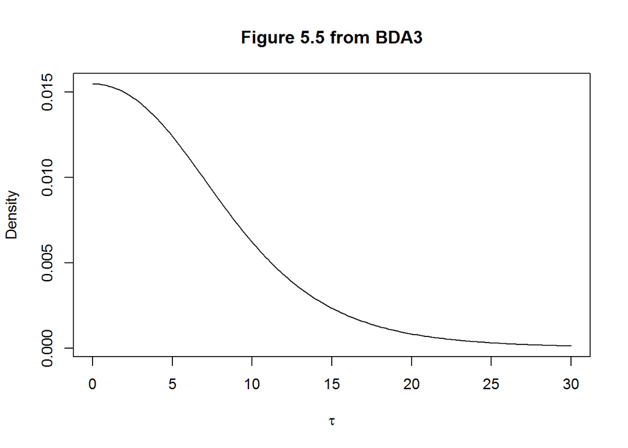

```r
samps           <- 200

hyper.prior     <-  function(tau) 1
tau.grid        <-  seq(0.001,30, length=samps)
pdf.tau         <-  sapply(tau.grid,function(x) marginal.tau(x))
pdf.tau         <-  pdf.tau/sum(pdf.tau)

plot(tau.grid,pdf.tau, type="l", main="Figure 5.5 from BDA3", xlab=expression(tau), ylab="Density")
```

The sampling method in BDA3 suggest to apply the inverse method from the posterior of $\tau$. I don’t do this for two reasons: (i) I’m not sure the posterior has a closed for solution for its inverse, and (ii) given that I already have the density, I can directly draw from that distribution sampling using the `sample` command (which leads me to think that this command applies the inverse method).

```r
# Sampling
s.tau           <- sample(tau.grid,samps,prob=pdf.tau, replace=TRUE)
s.mu            <- sapply(s.tau,function(x) rnorm(1,post.mu.hat(x),(post.v.mu(x))^0.5))
s.theta         <- NULL
for (j in 1:length(school.id)) {
  s.theta[[j]]         <- sapply(1:samps,
                            function(x)
                            rnorm(1,
                                  post.theta.j(s.mu[x],s.tau[x],j),
                                  (post.v.theta.j(s.tau[x],j))^0.5
                                  ) )
  }
```

**The following figures replicate the figures in pg 122 in BDA. Before doing the plots we need to ‘average over $\mu$’**

$\begin{aligned} E(\theta_{j}|\tau,y) &= E_{\mu}\left[E(\theta_{j}|\tau,y,\mu)|\tau,y\right] \nonumber \\ &= E_{\mu}\left[\frac{ \frac{1}{\sigma_{j}^{2}}y_{j} + \frac{1}{\tau^{2}}\mu }{\frac{1}{\sigma_{j}^{2}} + \frac{1}{\tau^{2} } }|\tau,y\right] = \frac{ \frac{1}{\sigma_{j}^{2}}y_{j} + \frac{1}{\tau^{2}}\hat{\mu} }{\frac{1}{\sigma_{j}^{2}} + \frac{1}{\tau^{2} } }\\ \nonumber \\ Var(\theta_{j}|\tau,y) &= E_{\mu}\left[Var(\theta_{j}|\tau,y,\mu)|\tau,y\right] + Var_{\mu}\left[E(\theta_{j}|\tau,y,\mu)|\tau,y\right] \nonumber \\ &= \frac{1}{\frac{1}{\sigma_{j}^{2}} + \frac{1}{\tau^{2} }} + V_{\mu}\left(\frac{\frac{1}{\tau^{2}}}{\frac{1}{\sigma_{j}^{2}} + \frac{1}{\tau^{2} }}\right) \end{aligned}$

Where $V_{\mu}$ and $\hat{\mu}$ correspond to the expressions defined in Eq 5.20 of BDA3. Below is the code and plot of both equations.

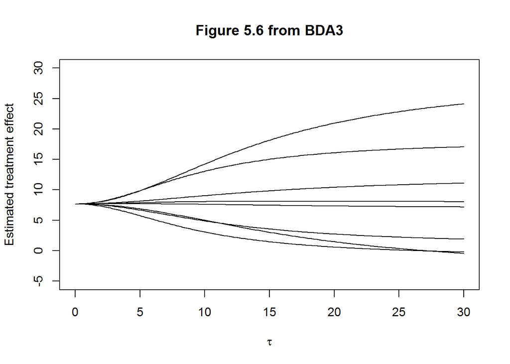

```r
post.theta.j.no.mu     <- function(tau,j) post.theta.j(post.mu.hat(tau),tau,j)
post.se.theta.j.no.mu  <- function(tau,j) sqrt( (post.v.theta.j(tau,j)) * (1+post.v.mu(tau)*tau^(-2)) )

plot( tau.grid,sapply(tau.grid, function(x) post.theta.j.no.mu(x,1)), type="l", ylim=c(-5,30), xlab="", ylab="")
lines(tau.grid,sapply(tau.grid, function(x) post.theta.j.no.mu(x,2)))
lines(tau.grid,sapply(tau.grid, function(x) post.theta.j.no.mu(x,3)))
lines(tau.grid,sapply(tau.grid, function(x) post.theta.j.no.mu(x,4)))
lines(tau.grid,sapply(tau.grid, function(x) post.theta.j.no.mu(x,5)))
lines(tau.grid,sapply(tau.grid, function(x) post.theta.j.no.mu(x,6)))
lines(tau.grid,sapply(tau.grid, function(x) post.theta.j.no.mu(x,7)))
lines(tau.grid,sapply(tau.grid, function(x) post.theta.j.no.mu(x,8)))
title(main="Figure 5.6 from BDA3", xlab=expression(tau), ylab="Estimated treatment effect")
```

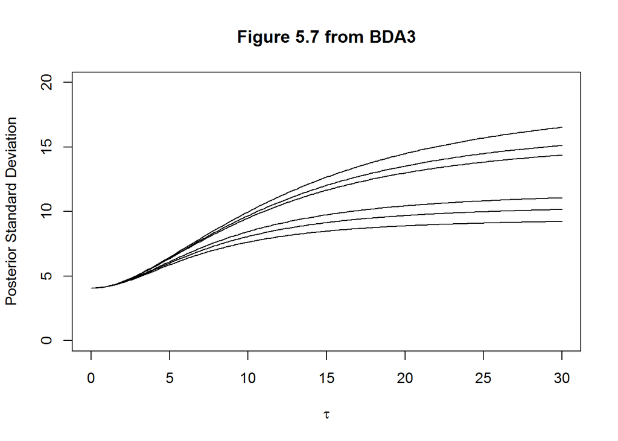

```r
plot(tau.grid,sapply(tau.grid, function(x)  post.se.theta.j.no.mu(x,1)), type="l", ylim=c(0,20), xlab="", ylab="")
lines(tau.grid,sapply(tau.grid, function(x) post.se.theta.j.no.mu(x,2)))
lines(tau.grid,sapply(tau.grid, function(x) post.se.theta.j.no.mu(x,3)))
lines(tau.grid,sapply(tau.grid, function(x) post.se.theta.j.no.mu(x,4)))
lines(tau.grid,sapply(tau.grid, function(x) post.se.theta.j.no.mu(x,5)))
lines(tau.grid,sapply(tau.grid, function(x) post.se.theta.j.no.mu(x,6)))
lines(tau.grid,sapply(tau.grid, function(x) post.se.theta.j.no.mu(x,7)))
lines(tau.grid,sapply(tau.grid, function(x) post.se.theta.j.no.mu(x,8)))
title(main="Figure 5.7 from BDA3", xlab=expression(tau), ylab="Posterior Standard Deviation")
```

```r
s.theta         <- matrix(unlist(s.theta), ncol = 8, byrow = FALSE)
s.theta.sort    <- apply(s.theta, 2, sort)
p               <- t( apply(s.theta.sort, 2, function(x) quantile(x,c(.025,.25,.5, .75, .975),type=1)) )
p               <- round(p,3)
```

**Table 5.3 from BDA3:**

| School |  |  |  |  |  |
| --- | --- | --- | --- | --- | --- |
|  | 2.5% | 25% | median | 75% | 97.5% |
| A | -1.287 | 6.127 | 9.702 | 14.719 | 32.959 |
| B | -5.205 | 3.904 | 7.958 | 11.727 | 22.622 |
| C | -11.529 | 1.932 | 7.345 | 11.119 | 21.305 |
| D | -4.456 | 3.535 | 7.369 | 11.092 | 19.771 |
| E | -11.326 | 0.956 | 6.303 | 9.364 | 18.245 |
| F | -5.954 | 2.578 | 6.999 | 10.396 | 17.554 |
| G | -0.544 | 7.096 | 10.007 | 14.477 | 26.717 |
| H | -6.289 | 3.54 | 7.725 | 11.798 | 22.223 |

Here we reproduce figure 5.8 (with the same problems as above)

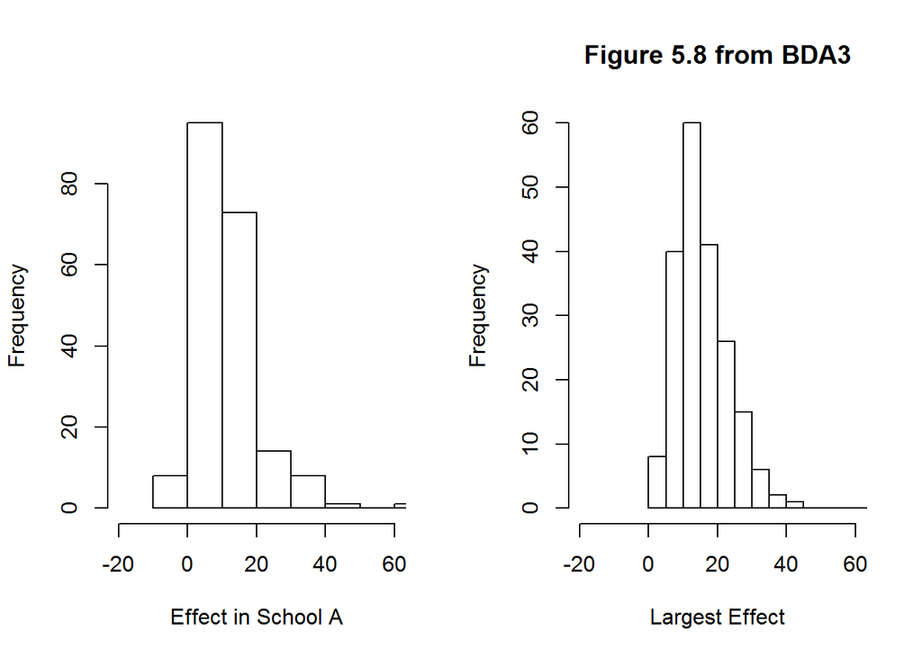

```r
par(mfrow=c(1,2))
domain           <- c(-20,60)
hist(s.theta[,1], breaks=10, xlab="Effect in School A", main="", xlim=domain)
hist(apply(s.theta,1,max), breaks=10, xlab="Largest Effect", main="", xlim=domain)
title(main="Figure 5.8 from BDA3")
```

This last figure (“largest effect”) is a good example of one the main advantage of a fully Bayesian hierarchical model: once we have correctly simulated the posterior, we can test all kinds of complicated hypothesis.

- 5.3a (i) - For each school $j$, the probability that its coaching program is the best of eight:  
  (**Important:** do not sort each posterior).

```r
aux1            <- apply(s.theta,1,max)
best            <- apply(1*(s.theta==aux1), 2,mean)
```

**Table 2: Probability that each coaching program is the best among the eight schools**

| School | Probability of having the best coaching program |
| --- | --- |
| A | 0.275 |
| B | 0.11 |
| C | 0.055 |
| D | 0.09 |
| E | 0.06 |
| F | 0.075 |
| G | 0.23 |
| H | 0.105 |

- 5.3a (ii) - For each school $j$, the probability that its coaching program is better than other school $k$:

```r
p               <- sapply( 1:8,
                          function(y) sapply( 1:8,
                                             function(x)
                                               mean( 1 * ( s.theta[,x] > s.theta[,y] ) )
                                             )
                          )
```

**Table 3: Probability that school $j$ (row) has a better program that school $k$ (column)**

| School $j$/School $k$ |  |  |  |  |  |  |  |  |
| --- | --- | --- | --- | --- | --- | --- | --- | --- |
|  | A | B | C | D | E | F | G | H |
| A | 0 | 0.64 | 0.7 | 0.655 | 0.725 | 0.69 | 0.49 | 0.625 |
| B | 0.36 | 0 | 0.565 | 0.54 | 0.66 | 0.58 | 0.365 | 0.475 |
| C | 0.3 | 0.435 | 0 | 0.465 | 0.555 | 0.48 | 0.3 | 0.42 |
| D | 0.345 | 0.46 | 0.535 | 0 | 0.62 | 0.545 | 0.355 | 0.49 |
| E | 0.275 | 0.34 | 0.445 | 0.38 | 0 | 0.425 | 0.275 | 0.385 |
| F | 0.31 | 0.42 | 0.52 | 0.455 | 0.575 | 0 | 0.295 | 0.43 |
| G | 0.51 | 0.635 | 0.7 | 0.645 | 0.725 | 0.705 | 0 | 0.625 |
| H | 0.375 | 0.525 | 0.58 | 0.51 | 0.615 | 0.57 | 0.375 | 0 |

- 5.3b (i) - Now with $\tau = \infty$ compute for each school $j$, the probability that it has the best coaching program:  
  With $\tau = \infty$ each school posterior effect is independent $\theta_{j} \sim N(y_{y}, \sigma_{j}^{2})$. The probability of a school having the best coaching program is:  
  **Wrong way to do it:**  
  $\begin{aligned} p(\theta_{j}>max_{i\neq j}\{\theta_{i}\}) &= \prod_{i\neq j} p(\theta_{j}>\theta_{i}) \\ &= \prod_{i\neq j} \Phi(\frac{\theta_{j} - \theta_{i}}{\sigma_{i}}) \end{aligned}$

**Right way to do it:**  
$\begin{aligned} p(\theta_{j}>max_{i\neq j}\{\theta_{i}\}) &= \int \prod_{i\neq j} p(\theta_{j}>\theta_{i}) \phi(\theta_{j}|y_{j},\sigma_{j})d\theta_{j} \\ &= \int \prod_{i\neq j} \Phi\left(\frac{\theta_{j} - \theta_{i}}{\sigma_{i}}\right) \phi(\theta_{j}|y_{j},\sigma_{j})d\theta_{j} \end{aligned}$

This integral has to be solved numerically:

```r
set.seed(142857)
best            <-  sapply(1:8,
                      function(y) mean( sapply( 1:1000 ,
                        function(x)
                          prod( pnorm( (
                            rnorm( 1 , effect[y] , se.effect[y] ) - effect[-y] ) /
                              se.effect[-y] ) ) )
                           )
                           )
# Ad-hoc normalization:
best            <- best/sum(best)
```

**Table 4: Probability that each coaching program is the best among the eight schools (with $\tau = \infty$)**

| School | Probability of having the best coaching program |
| --- | --- |
| A | 0.559927 |
| B | 0.0329844 |
| C | 0.0265477 |
| D | 0.0364362 |
| E | 0.0034413 |
| F | 0.0136409 |
| G | 0.1614563 |
| H | 0.1655662 |

- 5.3b (ii) - Now with $\tau = \infty$ compute for each school $j$, the probability that its coaching program is the better than other school $k$:  
  $\begin{aligned} p(\theta_{i}>\theta_{j}) &= p\left(-\frac{y_{j} - y_{i}}{\sqrt{\sigma_{i}^{2} + \sigma_{j}^{2}}} > \frac{(\theta_{j}-\theta_{i})- (y_{j} - y_{i})}{\sqrt{\sigma_{i}^{2} + \sigma_{j}^{2}}} \right) \\ &= \Phi\left( \frac{y_{i} - y_{j}}{\sqrt{\sigma_{i}^{2} + \sigma_{j}^{2}}}\right) \end{aligned}$

The following table presents the different values for the expression above:

```r
p               <- sapply(1:8,function(x)
                   sapply(1:8,function(y)
                  pnorm( q = 0, mean = (effect[x] - effect[y]) / sqrt(se.effect[x]^2 + se.effect[y]^2) ,
                  sd = 1 )
                  ) )
# Force all elementens in the diagonal to zero.
p               <- p - .5 * diag(8)
```

**Table 5: Probability that $j$ (row) has a better program that school $k$ (column). With $\tau = \infty$**

| School $j$/School $k$ |  |  |  |  |  |  |  |  |
| --- | --- | --- | --- | --- | --- | --- | --- | --- |
|  | A | B | C | D | E | F | G | H |
| A | 0 | 0.8663713 | 0.9212424 | 0.8705441 | 0.9513231 | 0.9266837 | 0.7104501 | 0.7526534 |
| B | 0.1336287 | 0 | 0.720053 | 0.5268155 | 0.748241 | 0.6811336 | 0.2397501 | 0.4229873 |
| C | 0.0787576 | 0.279947 | 0 | 0.3032674 | 0.4566223 | 0.4183914 | 0.1328547 | 0.2666945 |
| D | 0.1294559 | 0.4731845 | 0.6967326 | 0 | 0.713241 | 0.6501386 | 0.2296682 | 0.4063196 |
| E | 0.0486769 | 0.251759 | 0.5433777 | 0.286759 | 0 | 0.4440458 | 0.0789369 | 0.2591477 |
| F | 0.0733163 | 0.3188664 | 0.5816086 | 0.3498614 | 0.5559542 | 0 | 0.1264065 | 0.3010267 |
| G | 0.2895499 | 0.7602499 | 0.8671453 | 0.7703318 | 0.9210631 | 0.8735935 | 0 | 0.6146218 |
| H | 0.2473466 | 0.5770127 | 0.7333055 | 0.5936804 | 0.7408523 | 0.6989733 | 0.3853782 | 0 |

- 5.3c The estimated differences between the closed form solutions (5.3b) and the bayesian analysis (5.3a) is that the latter presents less extreme probability estimates (shrinkage)
- 5.3d If $\tau = 0$, then all effects are the same so the probabilities can be 0 or 1 for all schools (all are the largest effect and the smallest at the same time)
- **5.13 - Bicycles**

```r
#Load data
y                <- c(16, 9  , 10 , 13 , 19 , 20 , 18 , 17 , 35 , 55 )
n                <- c(74, 99 , 58 , 70 , 122, 77 , 104, 129, 308, 119)
```

- 5.13a $y_{i}\sim Bin(\theta_{i},n_{i})$ where $n_{i}$ represents the *total* number of vehicles (bicycles + other vehicles). $\theta_{i}\sim Beta(\alpha,\beta)$ the prior distribution of biking rates for each street. We set a non-informative hyper-prior $p(\alpha,\beta) \propto (\alpha + \beta)^{-5/2}$. This implies that the **joint posterior** distribution has the following (same as in equation 5.6 in BDA3):

$\begin{aligned} p(\theta,\alpha,\beta|y) &\propto p(\alpha, \beta)p(\theta|\alpha, \beta)p(y|\theta,\alpha, \beta) \nonumber \\ p(\theta,\alpha,\beta|y) &\propto p(\alpha, \beta)\prod^{J}_{j=1} \frac{\Gamma(\alpha + \beta)}{\Gamma(\alpha)\Gamma(\beta)} \theta_{j}^{\alpha - 1} (1 - \theta_{j})^{\beta - 1}\prod^{J}_{j=1} \theta_{j}^{y_{j}} (1 - \theta_{j})^{n_{j}-y_{j}}\label{bic.joint.post1} \end{aligned}$

- 5.13b Compute the marginal posterior of $\theta$, conditional on $\alpha, \beta$. For the beta-binomial case we have that given the hyper-parameters, each $\theta_{j}$ has a posterior distribution $Beta(\alpha + y_{j}, \beta +n_{j} - y_{j})$. Assuming exchangeability: $\begin{aligned} p(\theta|\alpha,\beta,y) &= \prod^{J}_{j=1} \frac{\Gamma(\alpha + \beta +n_{j})}{\Gamma(\alpha+y_{j})\Gamma(\beta+n_{j}-y_{j})} \theta_{j}^{\alpha+y_{j} - 1} (1 - \theta_{j})^{\beta+n_{j}-y_{j} - 1}\label{bic.cond.post.theta1} \end{aligned}$

Now we compute the posterior marginal of $(\alpha,\beta)$. Given that we do have a closed form solution in step 2, we compute the ratio of (\ref{bic.joint.post1}) and (\ref{bic.cond.post.theta1}).

$\begin{aligned} p(\alpha,\beta|y) &\propto \prod^{J}_{j=1} \frac{\Gamma(\alpha + \beta)}{\Gamma(\alpha)\Gamma(\beta)} \frac{\Gamma(\alpha+y_{j})\Gamma(\beta+n_{j}-y_{j})}{\Gamma(\alpha + \beta +n_{j})} \label{rat.marg.post.phi1} \end{aligned}$

Centering our grid around the methods of moments estimates for $(\alpha_{0}, \beta_{0})$:

$\begin{aligned} \hat{\mu} &= 0.1961412 = \frac{\hat{\alpha_{0}}}{\hat{\alpha_{0}}+\hat{\beta_{0}}}\\ \hat{\sigma^2} &= 0.0111207 = \frac{\hat{\alpha_{0}}\hat{\beta_{0}}}{(\hat{\alpha_{0}}+\hat{\beta_{0}})^{2}(\hat{\alpha_{0}}+\hat{\beta_{0}}+1)} \end{aligned}$

Solving form $(\hat{\alpha_{0}},\hat{\beta_{0}})$:

```r
#Here 'x' represents alpha and beta
dslnex          <- function(x) {
    z           <- numeric(2)
    z[1]        <- x[1]/(x[1]+x[2]) - mean(y/n)
    z[2]        <- x[1]*x[2]/(((x[1]+x[2])^2)*(x[1]+x[2]+1)) - sd(y/n)^2
    z
}

sol1            <- nleqslv(c(1,1), dslnex)
res1            <- paste("(",round(sol1$x[1],1), ",", round(sol1$x[2],1), ")",sep="")
```

We get: $(\hat{\alpha_{0}},\hat{\beta_{0}}) = (2.6,10.6)$.

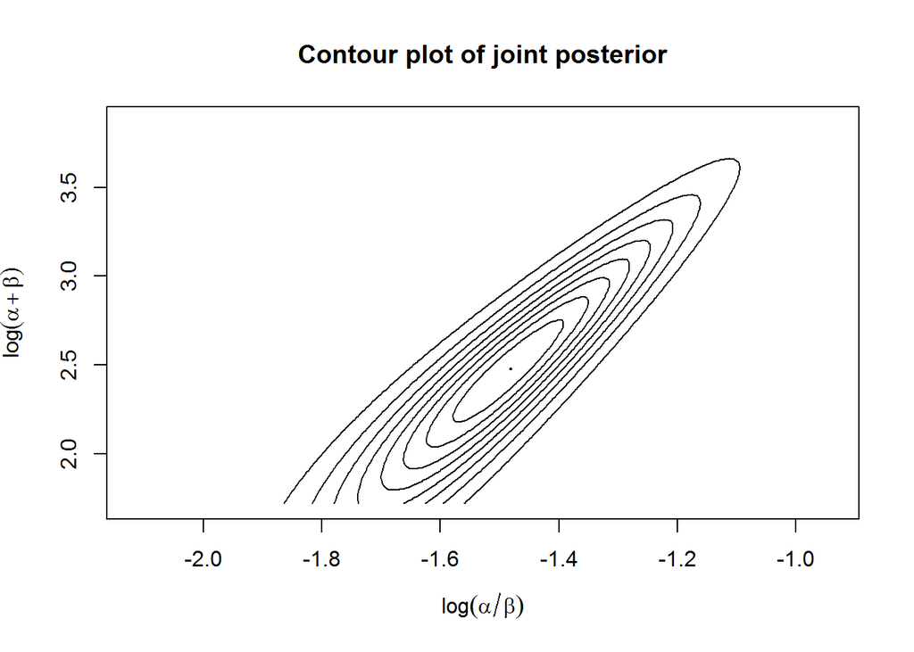

```r
bic.marg.post.phi <-   function(alpha, beta) {
  post          <-  1
  #notice the censoring in n (the gamma(.) function in R cannot handle large values)
  for (i in 1:length(y)) {
    if (n[i] > 100) n[i] = 100
    post  = post * (
      ( ( gamma(alpha + beta) ) /
        ( gamma(alpha) * gamma(beta) ) ) *
      ( ( gamma(alpha + y[i] ) * gamma(beta + n[i] - y[i]) ) /
        ( gamma(alpha + beta + n[i]) ) )
      )
  }
  # The hyper prior is defined below
  bic.hyper.prior(alpha,beta) * post
}

bic.hyper.prior <-  function(alpha,beta)
{
    alpha*beta*(alpha + beta)^(-5/2)
}

v1              <-  seq(log(sol1$x[1]/sol1$x[2])*1.5,log(sol1$x[1]/sol1$x[2])/1.5,length.out =151)
v2              <-  seq(log(sol1$x[1]+sol1$x[2])/1.5,log(sol1$x[1]+sol1$x[2])*1.5,length.out =151)
beta            <-  exp(v2)/(exp(v1)+1)
alpha           <-  exp(v2+v1)/(exp(v1)+1)

post.dens       <-  outer(alpha,beta,function(x1,x2) log(bic.marg.post.phi(x1, x2)) )
post.dens       <-  exp(post.dens - max(post.dens))
post.dens       <-  post.dens/sum(post.dens)

contours        <-  seq(min(post.dens), max(post.dens) , length=10)
contour(v1, v2, post.dens,
        levels=contours,
        xlab=expression( log(alpha/beta) ),
        ylab=expression( log(alpha+beta) ),
        xlim=c( min( v1 ), max( v1 ) ) ,
        ylim=c( min( v2 ), max( v2 ) ),
        drawlabels=FALSE,
        main="Contour plot of joint posterior")
```

Adjust the grid and repeat:

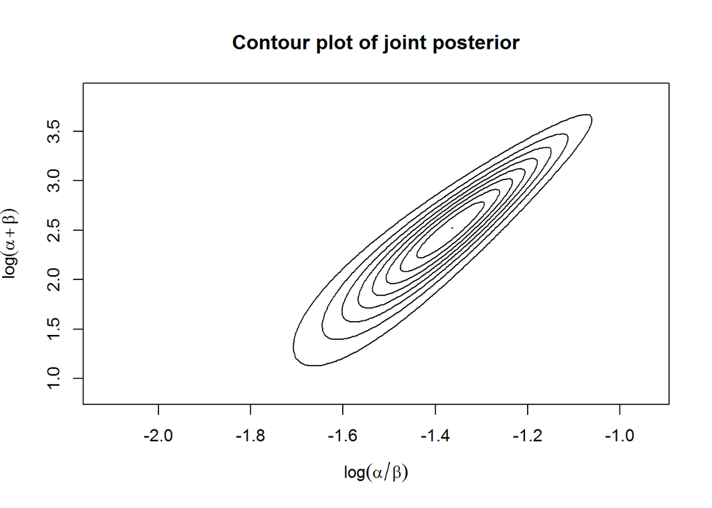

```r
v1              <-  seq(log(sol1$x[1]/sol1$x[2])*1.5,log(sol1$x[1]/sol1$x[2])/1.5,length.out =151)
v2              <-  seq(log(sol1$x[1]+sol1$x[2])/3,log(sol1$x[1]+sol1$x[2])*1.5,length.out =151)
beta            <-  exp(v2)/(exp(v1)+1)
alpha           <-  exp(v2+v1)/(exp(v1)+1)

post.dens       <-  outer(alpha,beta,function(x1,x2) log(bic.marg.post.phi(x1, x2)) )
post.dens       <-  exp(post.dens - max(post.dens))
post.dens       <-  post.dens/sum(post.dens)

contours        <-  seq(min(post.dens), max(post.dens) , length=10)
contour(v1, v2, post.dens,
        levels=contours,
        xlab=expression( log(alpha/beta) ),
        ylab=expression( log(alpha+beta) ),
        xlim=c( min( v1 ), max( v1 ) ) ,
        ylim=c( min( v2 ), max( v2 ) ),
        drawlabels=FALSE,
        main="Contour plot of joint posterior")
```

Draw samples $(\alpha^{s}, \beta^{s})$ from $p(\alpha,\beta|y)$ (finally!). Here we repeat the procedure used in section 3.(v) of the book replication document.

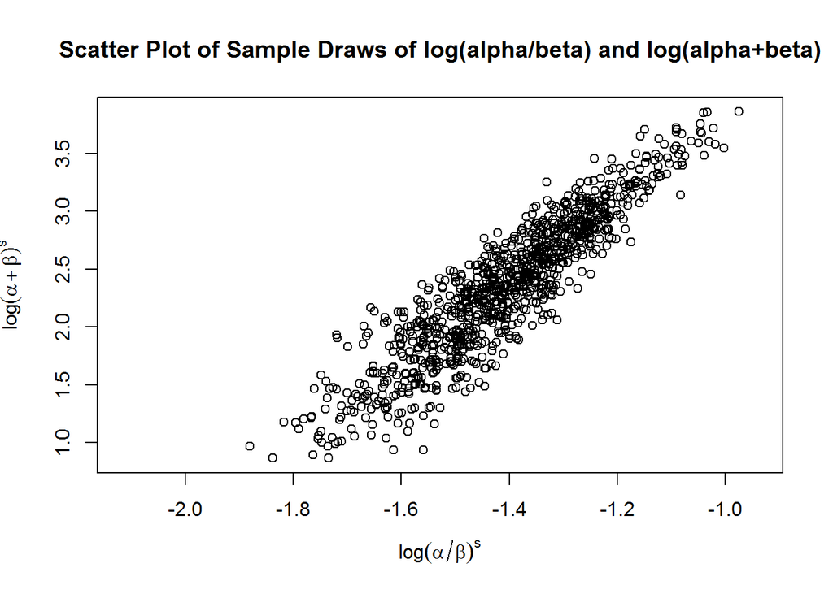

```r
samps           <-  1000
#Integrate (sum) over all beta to get the marginal of alpha
v1.dens         <-  apply(post.dens ,1, sum)
s.v1            <-  sample(v1, samps, replace=TRUE, prob = v1.dens)

#Select the colum of the joint density corresponding to a specific value of v1 (p(v2|v1))
cond.v2         <-  function(x)
{
  post.dens[which(v1 == s.v1[x]),]
}
#Sample a value of v2 according the the conditional probatility above
s.v2            <-  sapply(1:samps,function(x) sample(v2,1,replace=TRUE,prob=cond.v2(x)))

#Add a uniform random jitter centered at zero with with equal to the grid spacing. This will make the simulation draws more continuous. Plot the sampled values.
grid.v1         <-  v1[2] - v1[1]
grid.v2         <-  v2[2] - v2[1]
s.v2            <-  s.v2 + runif(length(s.v2),-grid.v2/2,grid.v2/2)
s.v1            <-  s.v1 + runif(length(s.v1),-grid.v1/2,grid.v1/2)
plot(s.v1, s.v2,
     xlab=expression( log(alpha/beta)^s ),
     ylab=expression( log(alpha+beta)^s ),
     xlim=c( min(v1) , max(v1) ) ,
     ylim=c( min(v2) , max(v2) ),
     main="Scatter Plot of Sample Draws of log(alpha/beta) and log(alpha+beta)")
```

By applying the inverse of the transformation we recover the marginal distribution of the original hyper-parameters.

```r
s.beta          <-  exp( s.v2 ) / ( exp(s.v1)+1 )
s.alpha         <-  exp( s.v2 + s.v1 ) / ( exp(s.v1)+1 )
```

- 5.13c For each draw of $\phi^{s}$, draw a sample of $\theta$ from $p(\theta|\phi^{s},y)$

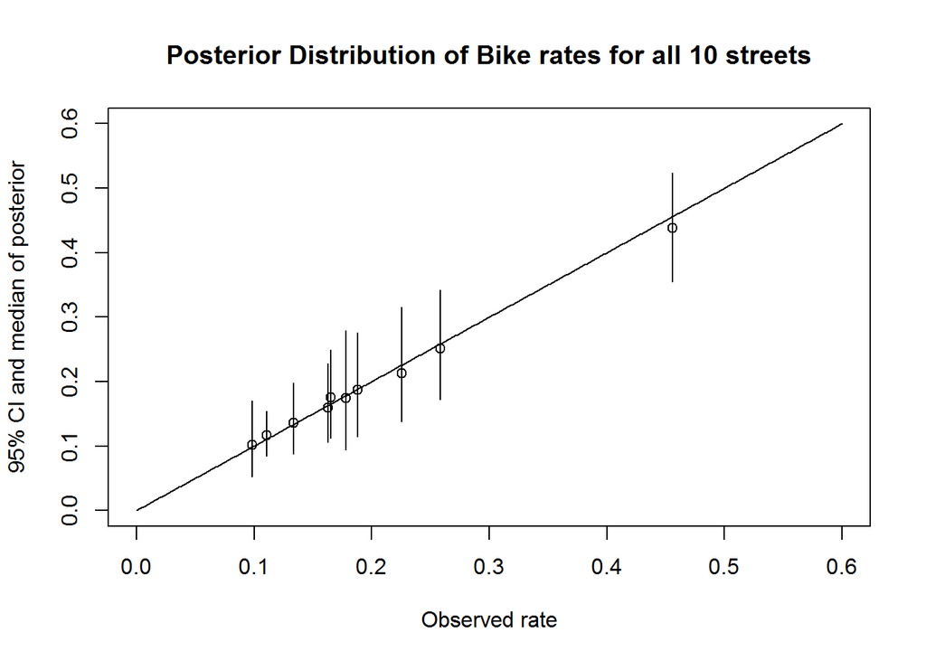

```r
theta.dist      <-  sapply(1:10,
                           function(x)
                             rbeta(1000, s.alpha+y[x], s.beta + n[x] - y[x])
                           )
theta.dist      <-  apply(theta.dist,2,sort)
plot(0:600/1000, 0:600/1000,
     type="l",
     xlab="Observed rate",
     ylab="95% CI and median of posterior")

jitter.x        <-  y/n + runif(length(y),-0.01,0.01)
points(jitter.x, theta.dist[500,])
segments(jitter.x,theta.dist[25,], jitter.x,theta.dist[975,] )
title(main="Posterior Distribution of Bike rates for all 10 streets")
```

The estimated proportions are almost the same as the raw proportions (no shrinkage).

- 5.13d We generate 1000 draws from a $Beta(\alpha^{s},\beta^{s})$ where the parameters come from the draws obtained above:

```r
s.theta         <- rbeta(1000, shape1 =s.alpha , shape2 = s.beta)
CI.num          <- round(s.theta[order(s.theta)][c(25,975)],2)
CI.str          <- paste("(" , CI.num[1] , "," , CI.num[2] , ")")
```

The posterior interval for $\hat{\theta} = ( 0.01 , 0.48 )$

- 5.13e If a new street is opening with 100 vehicles per day. The posterior interval predicts with 95% confidence that between 1 and 48. This CI is not so informative as it covers almost all the possible observed bike rates.
- 5.13f The beta assumption might not have been so reasonable as the posterior estimates did not show much shrinkage.
- **5.14**
- *5.14a* Set up a model in which the total number of vehicles observed at each location $j$ follows a Poisson distribution with parameter $\theta_{j}$, the ‘true’ rate of traffic per hour at the location. Assign a gamma population distribution for the parameters $\theta_{j}$ and a non-informative hyper-prior distribution. Write down the joint posterior distribution.

Now we have that $n_{j} \sim Poi(\lambda =\theta_{j})$ and $\theta_{j} \sim Gamma(\alpha)$. And the joint posterior is:

$\begin{aligned} p(\theta,\alpha,\beta|y) &\propto p(\alpha, \beta) \times p(\theta|\alpha, \beta) \times p(y|\theta,\alpha, \beta) \nonumber \\ p(\theta,\alpha,\beta|y) &\propto 1\times \prod_{j=1}^{10}Gamma(\theta_{j} | \alpha, \beta) \times \prod_{j=1}^{10}Poisson(y_{j}|\theta_{j}) \nonumber \\ &= \prod_{j=1}^{10}\frac{\beta^{\alpha}}{\Gamma(\alpha)}\theta_{j}^{\alpha-1}exp(-\beta \theta) \times \frac{\theta_{j}^{y_{i}}exp(-\theta_{j})}{!y_{j}} \nonumber \\ &\propto \frac{\beta^{n\alpha}}{\Gamma(\alpha)^{n}}exp(-\sum \theta_{j}( 1 + \beta )) \prod_{j=1}^{10} \theta_{j}^{\alpha + y_{j}-1} \label{bic.joint.post2} \end{aligned}$

- *5.14b*  
  Then compute the marginal posterior of $\theta$, conditional on $\alpha, \beta$. For the gamma-poisson case we have that given the hyper-parameters, each $\theta_{j}$ has a posterior distribution $Gamma(\alpha + n_{j}, \beta +1)$. Assuming exchangeability:

$\begin{aligned} p(\theta|\alpha,\beta,y) &\propto \prod_{j=1}^{10}Gamma(\theta_{j} | \alpha +y_{j}, \beta+1) \nonumber \\ &\propto \prod_{j=1}^{10}Gamma(\theta_{j} | \alpha +y_{j}, \beta+1) \nonumber \\ &\propto \prod_{j=1}^{10} \theta_{j}^{\alpha + y_{j} -1}exp(-(\beta+1) \theta_{j}) \label{bic.cond.post.theta2} \end{aligned}$

Now we compute the posterior marginal of $(\alpha,\beta)$. Given that we do have a closed form solution in step 2, we compute the ratio of (\ref{bic.joint.post2}) and (\ref{bic.cond.post.theta2}). $\begin{aligned} p(\alpha,\beta|y) &\propto \frac{\beta^{n\alpha}}{\Gamma(\alpha)^{n}} \prod_{i=1}^{n}\frac{\Gamma(\alpha+y_{i})}{(\beta + 1)^{\alpha+y_{i}}} \label{bic.marg.post.phi} \end{aligned}$

Centering our grid around the methods of moments estimates for $(\alpha_{0}, \beta_{0})$:

$\begin{aligned} \hat{\mu} &= 116 = \frac{\hat{\alpha_{0}}}{\hat{\beta_{0}}}\\ \hat{\sigma^2} &= 5141.7777778 = \frac{\hat{\alpha_{0}}}{\hat{\beta_{0}}^2} \end{aligned}$

Solving for $(\hat{\alpha_{0}},\hat{\beta_{0}})$:

```r
#Here 'x' represents alpha and beta
dslnex          <- function(x) {
    z           <- numeric(2)
    z[1]        <- x[1]/(x[2]) - mean(n)
    z[2]        <- x[1]/(x[2]^2) - sd(n)^2
    z
}

sol1            <- nleqslv(c(1,1), dslnex)
res1            <- paste("(",round(sol1$x[1],1), ",", round(sol1$x[2],2), ")",sep="")
```

We get: $(\hat{\alpha_{0}},\hat{\beta_{0}}) = (2.6,0.02)$.

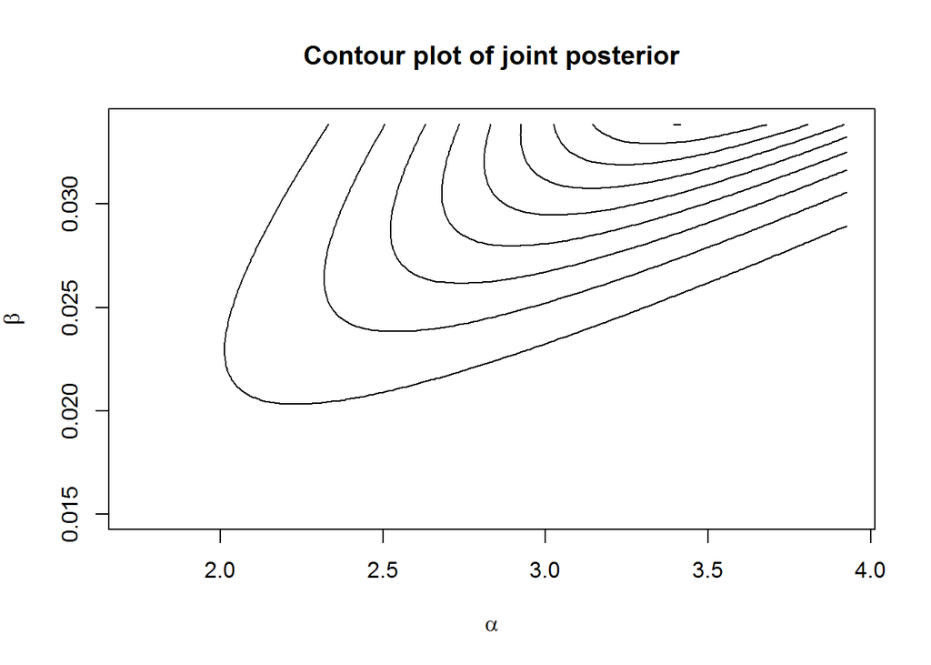

```r
bic.marg.post.phi <-   function(alpha, beta) {
  log.post          <-  0
  #notice the censoring in n
  for (i in 1:length(n))
  {
    if (n[i] > 100) n[i]  <-  100
    log.post        <-  log.post + log(gamma( alpha+n[i] )) - (alpha+n[i])*log((beta + 1))
  }
  # The hyper prior is defined below
  log(bic.hyper.prior2(alpha,beta)) + log.post + (length(n)*alpha)*log(beta) - length(n)*log(gamma(alpha))
}

bic.hyper.prior2 <-  function(alpha,beta) {
  1
}


alpha           <-  seq(sol1$x[1]/1.5,sol1$x[1]*1.5,length.out =151)
beta            <-  seq(sol1$x[2]/1.5,sol1$x[2]*1.5,length.out =151)

post.dens       <-  outer(alpha,beta,function(x1,x2) bic.marg.post.phi(x1, x2) )
post.dens       <-  exp(post.dens - max(post.dens))
post.dens       <-  post.dens/sum(post.dens)



contours        <- seq(min(post.dens), max(post.dens), length=10)
contour(alpha, beta, post.dens,levels=contours, xlab=expression(alpha), ylab=expression(beta), xlim=c(min(alpha),max(alpha)) , ylim=c(min(beta),max(beta)), drawlabels=FALSE, main="Contour plot of joint posterior")
```

Adjust the grid and repeat:

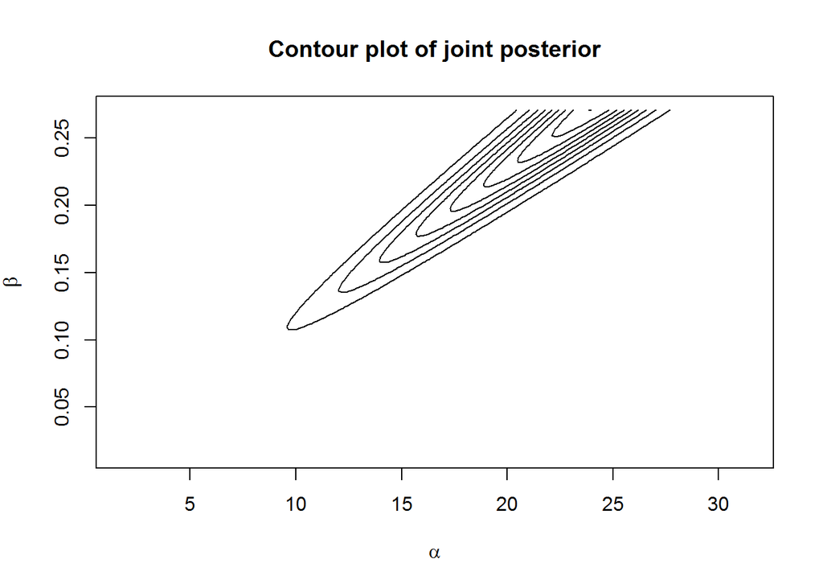

```r
alpha           <-  seq(sol1$x[1]/1.5,sol1$x[1]*12,length.out =151)
beta            <-  seq(sol1$x[2]/1.5,sol1$x[2]*12,length.out =151)

post.dens       <-  outer(alpha,beta,function(x1,x2) bic.marg.post.phi(x1, x2) )
post.dens       <-  exp(post.dens - max(post.dens))
post.dens       <-  post.dens/sum(post.dens)

contours        <- seq(min(post.dens), max(post.dens) , length=10)
contour(alpha, beta, post.dens,levels=contours, xlab=expression(alpha), ylab=expression(beta), xlim=c(min(alpha),max(alpha)) , ylim=c(min(beta),max(beta)), drawlabels=FALSE, main="Contour plot of joint posterior")
```

Draw samples $(\alpha^{s}, \beta^{s})$ from $p(\alpha,\beta|y)$.

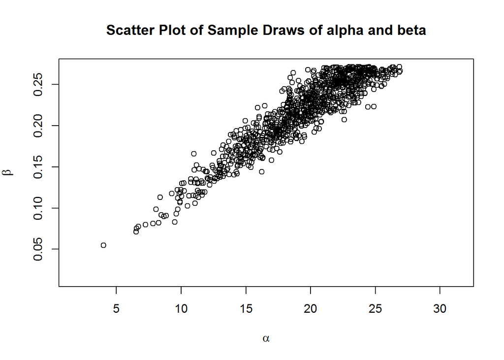

```r
samps           <-  1000
alpha.dens      <-  apply(post.dens ,1, sum)
s.alpha         <-  sample(alpha,samps, replace=TRUE, prob = alpha.dens)

#Select the colum of the joint density corresponding to a specific value of v1 (p(beta|alpha))
cond.beta       <-  function(x) {
  post.dens[which(alpha == s.alpha[x]),]
}
#Sample a value of v2 according the the conditional probatility above
s.beta          <-  sapply(1:samps,function(x) sample(beta,1,replace=TRUE,prob=cond.beta(x)))

#Add a uniform random jitter centered at zero with with equal to the grid spacing. This will make the simulation draws more continuous. Plot the sampled values.
grid.alpha      <-  alpha[2]-alpha[1]
grid.beta       <-  beta[2]-beta[1]
s.beta          <-  s.beta + runif(length(s.beta),-grid.beta/2,grid.beta/2)
s.alpha         <-  s.alpha + runif(length(s.alpha),-grid.alpha/2,grid.alpha/2)
plot(s.alpha, s.beta, xlab=expression(alpha), ylab=expression(beta), xlim=c(min(alpha),max(alpha)) , ylim=c(min(beta),max(beta)), main="Scatter Plot of Sample Draws of alpha and beta")
```

**Note:** regardless of how much I change the range of $\alpha$ and $\beta$ I don’t seem to cover the whole graph.

- *5.14c* Given the previous result we can say that the posterior is not integrable.
- *5.14d* I don’t know how to alter it such that it becomes integrable.
- **10.1**
- *10.1a*  
  If $\theta \sim N(\mu, \sigma_{\theta})$ then $R$ draws $y^{(r)}$ will have a simulation standard error of $\hat{\sigma_{\theta}}/\sqrt{R}$. Hence in order to be within $0.1 \sigma_{\theta}$ we need $R=100$.
- *10.1b*  
  For the simulation exercise we choose $\mu=0, \sigma_{\theta}=1$. We perform R draws and for each set of simulated numbers, we compute the 2.5% percentile $\{y^{r}\}_{p=0.025}$ and its difference with the theoretical percentile (-1.96), we repeat this exercise 100 times and look at the average of the difference for different values of $R$.

```r
y_reps          <- apply(
                    sapply( 1:100,
                      function(x) sapply(10^(1:5),
                        function(x) abs(-1.96 - quantile(rnorm(x, mean=0, sd=1) , c(.025) ) ) )
                          ), 1, mean
                        )
```

**Table 6: Standard Error of Simulations**

| $R$ | $\|\{y^{r}\}_{p=0.025} + 1.96\|$ |
| --- | --- |
| 10 | 0.6377631 |
| 100 | 0.1822381 |
| 1000 | 0.0670143 |
| 10000 | 0.0233484 |
| 100000 | 0.0072465 |

**Note:** both results don’t match.

- **10.4a**  
  I follow [this proof](http://www.stat.columbia.edu/~gelman/book/solutions3.pdf).

We want to prove that $g(\theta|acceptance) = p(\theta)$. The pdf of a drawn from using the rejection sampling algorithm follows:

$\begin{aligned} Pr(\theta \leq \theta^{*} | \theta \text{ is accepted }) &= Pr(\theta \leq \theta^{*} | U \leq \frac{p(\theta)}{Mg(\theta)}) \nonumber \\ \nonumber \\ &= \frac{Pr(\theta \leq \theta^{*} \text{ and } U \leq \frac{p(\theta)}{Mg(\theta)})}{Pr(U \leq \frac{p(\theta)}{Mg(\theta)})} \nonumber \\ \nonumber \\ &= \frac{ \int_{-\infty}^{\theta^{*}} \int_{0}^{\frac{p(\theta)}{Mg(\theta)}} g(\theta) dud\theta }{ \int_{-\infty}^{\infty} \int_{0}^{\frac{p(\theta)}{Mg(\theta)}} g(\theta) dud\theta } \nonumber \\ \nonumber \\ &= \frac{ \int_{-\infty}^{\theta^{*}} \left [\frac{p(\theta)}{Mg(\theta)} - 0 \right ] g(\theta) dud\theta }{ \int_{-\infty}^{\infty} \left [\frac{p(\theta)}{Mg(\theta)} - 0 \right ]g(\theta) dud\theta } \nonumber \\ &= \int_{-\infty}^{\theta^{*}} p(\theta) d\theta \quad \blacksquare \end{aligned}$

**Note:** I was note able to map perfectly this proof with this [other one](http://www.columbia.edu/~ks20/4703-Sigman/4703-07-Notes-ARM.pdf). that seems more complete. For the proof presented here, my main doubt regards the step between the second and third line.

- **11.2 [CHECK WITH SUSAN]**  
  Replicate the computations for the bioassay example of section 3.7 using the Metropolis algorithm. Be sure to define your starting points and your jumping rule.

From 3.7 we have that the posterior of $\alpha$ and $\beta$ follows: $\begin{aligned} p(\alpha,\beta|y,n,x) \propto \prod_{i=1}^{k} p(y_{i}|\alpha,\beta,n_{i},x_{i}) \label{post.1} \end{aligned}$

$\begin{aligned} p(y_{i}|\alpha,\beta,n_{i},x_{i}) \propto [logit^{-1}(\alpha +\beta x_{i})]^{y_i}[1-logit^{-1}(\alpha +\beta x_{i})]^{n_{i}- y_{i}} \end{aligned}$

Our starting values will be the ML estimates.

```r
# Data
x               <-  c(-0.86, -0.30, -0.05,  0.73)
y               <-  c(0, 1, 3, 5)
n               <-  rep(5,4)

# ML estimation
mlfit <- glm( cbind(y, n-y) ~ x, family = binomial)
mlfit$coefficients = round(mlfit$coefficients*1000)/1000
res1 = paste(paste("(",mlfit$coefficients[1], sep=""), paste(mlfit$coefficients[2],")", sep=""), sep=",")
```

With the estimates $(\hat{\alpha_{0}},\hat{\beta_{0}}) = (0.847,7.749)$.

Now we will simulated values of $\alpha$ and $\beta$ using the Metropolis algorithm. Our jumping function will be a bi-variate normal. We will start with a variance of $1\times I$ and tweak in in order to get an acceptance ratio between 20% and 50%.

**Note for Susan:** So far I have not been able to get convergence bellow.

```r
posterior       <-  function(arg1) {
  alpha         <- arg1[1]
  beta          <- arg1[2]
  posterior     <-  1
  for (i in 1:length(y)) {
    posterior   <-  posterior * (   ( ( inv.logit( alpha + beta * x[i] ) )^y[i] ) *
                                    ( ( 1 - inv.logit( alpha + beta * x[i] ) )^( n[i] - y[i] ) )
                              )
  }
  posterior
}

#THERE HAS TO BE SOME ERROR IN THE CODE AS MY ALGORITH KEEP DIVERGING
  jumping         <- function(theta, scale=.1) rmvnorm(1, mean = theta, sigma = scale * diag(2))
  d.jumping       <- function(theta, theta_1, scale=.1) dmvnorm(theta, theta_1, scale * diag(2))

  sims            <-  2000
  theta           <-  matrix(0,nrow = sims, ncol = 2)
  accept          <-  rep(0,sims)
  r.all           <-  rep(0,sims)
  theta[1,]       <-  mlfit$coefficients


  for (i in 2:sims)
  {
    theta.star      <-  jumping(theta[i-1,], .1)
    #print(i)
      r             <-  min( exp(
                            ( log( posterior(theta.star) ) ) -
                            ( log( posterior(theta[i-1,])) )
                            ), 1)

    r.all[i]        <-  r
    #print(r)
    if ( r < runif(1) )
    {
      theta[i,]     <- theta.star
      accept[i]     <- 1
    }
    else
    {
      theta[i,]     <- theta[i-1,]
      accept[i]     <- 0
    }
    sum(accept)
  }
```

- **11.3**  
  Given the following data:

```r
df              <-  data.frame(machine = rep(1:6, each=5), measure = c(83, 92, 92, 46, 67,
                                                                       117, 109, 114, 104, 87,
                                                                       101, 93, 92, 86, 67,
                                                                       105, 119, 116, 102, 116,
                                                                       79, 97, 103, 79, 92,
                                                                       57, 92, 104, 77, 100))

J               <- length(unique(df$machine))
n               <- length(df$measure)
```

Implement a separate, a pooled and a hierarchical Gaussian model with common variance described in section 11.6. Run the simulations long enough for appropriate convergence. Using each of three models -separate, pooled, and hierarchical- report: (i) the posterior distribution of the mean of the quality measurements of the sixth machine, (ii) the predictive distribution for another quality measurement of the sixth machine, and (iii) the posterior distribution of the mean of the quality measurements of the seventh machine.

*The Hierarchical Model*  
Data $y_{ij}, i= 1,...,5 , j= 1,..,6$ are iid within each of $J$ groups with $y_{ij} \sim N(\theta_{j}, \sigma^{2})$. The prior distribution of $\theta_{j}$ is assume to be normal with hyper-parameters $\mu, \tau$ ($\theta_{j} \sim N(\mu, \tau^{2})$), $\sigma$ is assumed to be unknown and the hyper-prior is assumed to be uniform over $(\mu, log(\sigma), \tau)$, which implies $p(\mu, log(\sigma), log(\tau)) \propto \tau$. The joint posterior density for all the parameters is:

$\begin{aligned} p(\theta,\mu, log(\sigma), log(\tau) | y) \propto \tau \prod^{J}_{j=1} N(\theta_{j}|\mu, \tau^{2}) \prod^{J}_{j=1} \prod^{n_{j}}_{i=1} N(y_{ij}|\theta_{j}, \sigma^{2}) \label{norm.norm4gibs} \end{aligned}$

*Starting points*  
Select 10 $\theta_{j}$ randomly from the $y_{ij}$ sample. And take $\mu$ to be the average starting values of $\theta_{j}$.

```r
set.seed(142857)
theta.0         <- sapply(1:6,function(x) sample(df$measure[df$machine==x],10, replace=TRUE))
mu.0            <- apply(theta.0, 1,mean)
```

*1. Draw from conditional posterior of $\tau^{2}$* using: $\begin{aligned} \hat{\tau}^{2} &= \frac{1}{J-1}\sum_{j=1}^{J}(\theta_{j} - \mu)^{2} \end{aligned}$

```r
tau.hat.2       <- function(theta) {
  mu            <- mean(theta)
  tau.2         <- ( 1/(J-1) ) * sum((theta - mu)^2)
  return(tau.2)
}
```

And the fact that: $\begin{aligned} \tau^{2}|\theta,\mu,\sigma, y \sim Inv-\chi^2(J-1,\hat{\tau}^{2}) \end{aligned}$

We can draw samples for $\tau^{2}$

```r
s.tau.post      <- function(theta) {
  tau.2         <- tau.hat.2(theta)
  tau.cond      <- (J - 1) * (tau.2)/rchisq(1,J-1)
  return(tau.cond)
  }
```

*2. Draw from conditional posterior of $\sigma^{2}$* Using:  
$\begin{aligned} \hat{\sigma}^{2} &= \frac{1}{n}\sum_{j=1}^{J}\sum_{i=1}^{n_{j}}(y_{ij} - \theta_{j})^{2} \end{aligned}$

```r
f.sigma.hat.2   <- function(theta) {
  sigma.hat.2   <-  sapply(1:6, function(x) (df$measure[df$machine==x] - theta[x])^2)
  sigma.hat.2   <-  (1/n) * sum(unlist(sigma.hat.2))
  return(sigma.hat.2)
}
```

And the fact that:

$\begin{aligned} \sigma^{2}|\theta,\mu,\tau,y \sim Inv-\chi^2(n,\hat{\sigma}^{2}) \end{aligned}$ We can draws samples for $\sigma^{2}$

```r
s.sigma.post      <-  function(theta) {
  sigma2.hat      <- f.sigma.hat.2(theta)
  sigma2.post      <-  (n) * (sigma2.hat)/rchisq(1,n)
  return(sigma2.post)
  }
```

*3. Draw from conditional posterior of $\mu$* Using:  
$\begin{aligned} \hat{\mu} &= \frac{1}{J} \sum_{j=1}^{J}\theta_{j} \end{aligned}$

```r
mu.hat          <- function(theta) {
  mean(theta)
}
```

And the fact that:

$\begin{aligned} \mu|\theta,\sigma,\tau,y \sim N(\hat{\mu}, \tau^{2}/J) \end{aligned}$

We can draw values for $\mu$

```r
s.mu        <- function(theta,tau2) {
  mu.hat    <- mu.hat(theta)
  rnorm(1,mu.hat,sqrt(tau2/J))
}
```

*4. Finally, we can draw values for $\theta$* Using the fact that:  
$\begin{aligned} \theta_{j}|\mu,\sigma,\tau,y \sim N(\hat{\theta_{j}}, V_{\theta_{j}}) \end{aligned}$  
With: $\begin{aligned} \hat{\theta_{j}} &= \frac{ \frac{1}{\tau^{2}}\mu + \frac{n_{j}}{\sigma^{2}}\bar{y_{\dot j}} }{\frac{1}{\tau^{2}} + \frac{n_{j}}{\sigma^{2}}} \nonumber \\ \\ V_{\theta_{j}} &= \frac{1}{\frac{1}{\tau^{2}} + \frac{n_{j}}{\sigma^{2}}} \nonumber \\ \end{aligned}$

```r
theta.hat.j     <- function(j,mu,sigma2,tau2) {
  y.bar.j       <- mean(df$measure[df$machine==j])
  n.j           <- length(df$measure[df$machine==j])
  ( (1/tau2) * mu + (n.j/sigma2) * y.bar.j  ) / ( (1/tau2) + (n.j/sigma2)  )
}

V.theta.hat.j   <- function(j,mu,sigma2,tau2) {
  n.j           <- length(df$measure[df$machine==j])
  ( 1 ) / ( (1/tau2) + (n.j/sigma2) )
}

s.theta         <- function(mu,sigma2,tau2) {
  theta         <- NULL
  for (j in 1:J) {
    t.hat       <- theta.hat.j(j,mu,sigma2,tau2)
    v.t.hat     <- V.theta.hat.j(j,mu,sigma2,tau2)
    theta[j]    <- rnorm(1,t.hat,sqrt(v.t.hat))
  }
  return(theta)
}

sims          <- 200
mcmc.gibbs      <- function(chain) {
  res1          <- as.list(NULL)
  param         <- 9
  s.param       <- matrix(NA, ncol = param, nrow = sims )
  colnames(s.param)<-  c("theta1", "theta2", "theta3", "theta4", "theta5", "theta6", "mu", "sigma2", "tau2")
  s.param[1,1:6]<- theta.0[chain,]
  s.param[1,9]  <- s.tau.post(theta.0[chain,])
  s.param[1,8]  <- s.sigma.post(theta.0[chain,])
  s.param[1,7]  <- s.mu(theta.0[chain,],s.param[1,9])

  for (s in 2:sims) {
    s.param[s,1:6]<- s.theta(s.param[s-1,7],s.param[s-1,8],s.param[s-1,9])
    s.param[s,9]  <- s.tau.post(s.param[s,1:6])
    s.param[s,8]  <- s.sigma.post(s.param[s,1:6])
    s.param[s,7]  <- s.mu(s.param[s,1:6],s.param[s,9])
  }
return(s.param)
#Warm-up
}
s.param           <- lapply(1:10, function(x) mcmc.gibbs(x))
s.param.1         <- s.param[[1]][101:200, ]

#Transform the variance in to sd.
s.param.1[,8:9]   <- sqrt(s.param.1[,8:9] )

t(apply(s.param.1,2, function(x) quantile(x, c(.025,.25,.5,.75,.975))))
```

```
##             2.5%        25%       50%       75%     97.5%
## theta1 68.226089  75.421107  80.39244  85.48695  94.65629
## theta2 90.198936  96.618055 101.97768 107.76752 113.77738
## theta3 78.833357  85.921457  89.34768  93.42686  99.81877
## theta4 94.264990 102.451558 106.88234 111.32589 118.46376
## theta5 79.180597  87.179518  90.30892  94.51635  98.87628
## theta6 75.661817  84.683794  87.73719  91.37322  97.42413
## mu     83.438952  88.912486  92.94220  96.81082 105.40103
## sigma2 10.986146  12.872836  14.69001  16.11049  19.45944
## tau2    4.626044   8.358545  12.10177  16.47120  29.15127
```

```r
r.hat             <- function(arg1) {
  n               <- dim(arg1)[1]
  m               <- dim(arg1)[2]
  B               <- (n/(m-1)) * sum( ( apply(arg1,2,mean) - mean(arg1) )^2 )
  W               <- (1/m) * (1/(n-1)) * sum( (arg1 - apply(arg1,2,mean))^2 )
  sqrt( (n-1)/(n) + B/(W*n) )
}

 #r.hat(sapply(1:10,function(x) s.param[[x]][,4] ))
```

In addition, the separate and pooled models estimators of the mean of the sixth machine are both normal with means and variances defined by **[Susan: I’m not so sure of the following definitions. If wrong, could you show me the correct answer?]**:

$\begin{aligned} \bar{y_{\cdot \cdot}} &= \frac{ \sum_{i=1}^{5} \sum_{j=1}^{6} y_{ij} }{5\times 6} \quad &V^{pooled}_{6} = \frac{ \sum_{i=1}^{5} \sum_{j=1}^{6} (y_{i6} - \bar{y_{\cdot \cdot}})^{2} }{5\times 6 -1} \\ \bar{y_{6 \cdot}} &= \frac{ \sum_{i=1}^{5} y_{6j} }{5} \quad &V^{sep}_{6} = \frac{ \sum_{i=1}^{5} (y_{i6} - \bar{y_{6 \cdot}} )^{2}}{5 - 1} \end{aligned}$

```r
y.bar.dot.dot   <-  mean(df$measure)
var.pooled      <-  sum( (df$measure[df$machine==6] - mean(df$measure))^2 )/( length(df$measure) - 1)
s.theta.pooled.6<- rnorm(sims, y.bar.dot.dot, sqrt(var.pooled))
y.bar.6.dot     <-  mean(df$measure[df$machine==6])
var.sep.6       <-  sum( (df$measure[df$machine==6] - mean(df$measure[df$machine==6]))^2 )/( length(df$measure[df$machine==6]) - 1)
s.theta.sep.6   <- rnorm(sims, y.bar.6.dot, sqrt(var.sep.6))
```

Now we can answer the original questions:  
- (i) The posterior distribution of the mean of the quality measurements of the sixth machine.  
For the hierarchical, pooled and separate models: draw from $N(\theta_{6}, \sigma^{2}), N(\bar{y_{\cdot \cdot}}, V^{pooled}_{6}), N(\bar{y_{6 \cdot}} , V^{sep}_{6})$. The results are summarize in the following plot:

[figure not shown]

```r
plot(density(s.param.1[,"theta6"]), col="red", xlab="Mean Measure",
    ylab="Density", main="Distribution of Mean 7th Measure under Three Models")
lines(density(s.theta.pooled.6), col="blue")
lines(density(s.theta.sep.6), col="green")
legend("topleft",col = c("red","blue", "green") ,legend=c("Hierarchical","pooled", "separated"),lty = c(1,1,1))
```

- 2. The predictive distribution for another quality measurement of the sixth machine.

**I was not able to think of a way to sample for this part, I would appreciate suggestions**

- 3. The posterior distribution of the mean of the quality measurements of the seventh machine.  
     For the hierarchical, pooled and separate models: draw from $N(\mu, \tau), N(\bar{y_{\cdot \cdot}}, V^{pooled}_{6}), N(\bar{y_{6 \cdot}} , V^{sep}_{6})$. The results are summarize in the following plot:

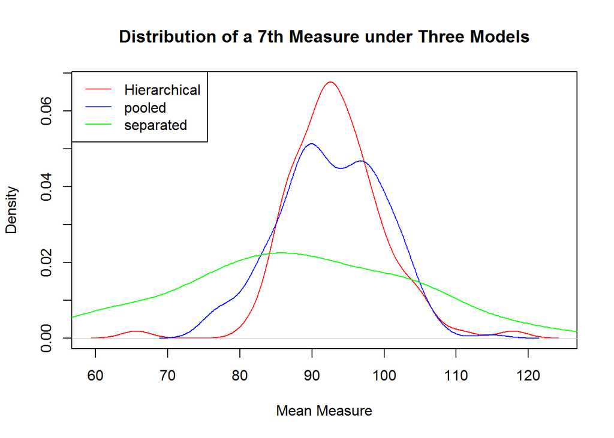

```r
plot(density(s.param.1[,"mu"]), col="red", xlab="Mean Measure",
    ylab="Density", main="Distribution of a 7th Measure under Three Models")
lines(density(s.theta.pooled.6), col="blue")
lines(density(s.theta.sep.6), col="green")
legend("topleft",col = c("red","blue", "green") ,legend=c("Hierarchical","pooled", "separated"),lty = c(1,1,1))
```

- **11.6a**  
  For any given scalar estimand $\phi$, the simulation methods studied in chapter 11 generate *chains* of random numbers. It is common practice to delete (warm-up) the first half of each chain. The resulting half is usually split in to two new halfs. Denote $n$ the length of each resulting chain, and $m$ the number of such chains. Show that:  
  $\begin{aligned} \lim_{n \to \infty} mn \, var(\bar{\psi_{\cdot \cdot}}) &= \left(1 + 2 \sum_{t=1}^{\infty} \rho_{t} \right) var(\psi|y), \end{aligned}$  
  Where: $\begin{aligned} \bar{\psi_{\cdot \cdot}} &= \frac{1}{m} \sum_{j=1}^{m} \bar{\psi_{\cdot j}}, \quad \text{and}\quad \bar{\psi_{\cdot j}} &= \frac{1}{n} \sum_{i=1}^{n} \bar{\psi_{i j}} \nonumber \end{aligned}$

Then we have:

$\begin{aligned} var(\bar{\psi_{\cdot \cdot}}) &= \frac{1}{(mn)^{2}} \left( \sum_{i} \sum_{j} var(\psi_{ij}|y) + 2\sum_{i} \sum_{j} \sum_{k\neq i} \sum_{l \neq j} cov(\psi_{ij}, \psi_{kl}|y) \right) \\ &= \frac{1}{(mn)^{2}} mn \, var(\psi|y) \left( 2\sum_{i} \sum_{j} \sum_{k\neq i} \sum_{l \neq j} corr(\psi_{ij}, \psi_{kl}|y) \right) \\ \dots \end{aligned}$

I was not able to show that the term inside the parenthesis was equal to $\sum_{t=1}^{\infty} \rho_{t}$.

- **12**  
  Install and run examples in STAN [DONE]
- **14.1**

```r
# Analysis of Radon measures
y.1             <-  c(5.0, 13.0, 7.2, 6.8, 12.8, 5.8, 9.5, 6.0, 3.8, 14.3, 1.8, 6.9, 4.7, 9.5)
y.2             <-  c(0.9, 12.9, 2.6, 3.5, 26.6, 1.5, 13.0, 8.8, 19.5, 2.5, 9.0, 13.1, 3.6, 6.9)
y.3             <-  c(14.3, 6.9, 7.6, 9.8, 2.6, 43.5, 4.9, 3.5, 4.8, 5.6, 3.5, 3.9, 6.7)
basement.1      <-  c(1,1,1,1,1,0,1,1,1,0,1,1,1,1)
basement.2      <-  c(0,1,1,0,1,1,1,1,1,0,1,1,1,0)
basement.3      <-  c(1,0,1,0,1,1,1,1,1,1,1,1,1)
counties        <-  rep(1:3,c(length(y.1),length(y.2),length(y.3)))
y               <-  c(y.1,y.2,y.3)
indicators      <-  as.matrix(table(1:length(counties), counties))
x               <-  cbind(basement=c(basement.1,basement.2,basement.3), indicators)
colnames(x)     <-  c("basement","countie1", "countie2", "countie3")
lf.1            <-  summary( lm(log(y)~x-1) )

nsim <- 10000
n <- nrow(x)
k <- ncol(x)

s.sigma           <- lf.1$sigma*sqrt((n-k)/rchisq(nsim,n-k))
s.beta            <- matrix(rep(lf.1$coefficients[,1], 2), ncol=4, nrow=nsim, byrow = TRUE) +
  matrix(rnorm( nsim * k), nrow = nsim, ncol = k ) %*% chol( vcov(lf.1) ) * s.sigma/lf.1$sigma
```

- **14a**  
  Fit a linear regression to the logarithms of the radon measurements (`y`), with indicator variables for the three counties and for whether a measurement was recorded on the first floor. Summarize your posterior inference in nontechnical terms.

**Answer:** after estimating the posterior of the parameters we can explore the potential of the bayesian approach. Given that we have an estimation of the full posterior of the parameters we could analyse the data in all sorts of ways. In the classical approach on the other hand, any time that we would like to explore the model beyond linear hypothesis, we would need to use the delta method and some derivations to obtain the distribution of each new hypothesis.

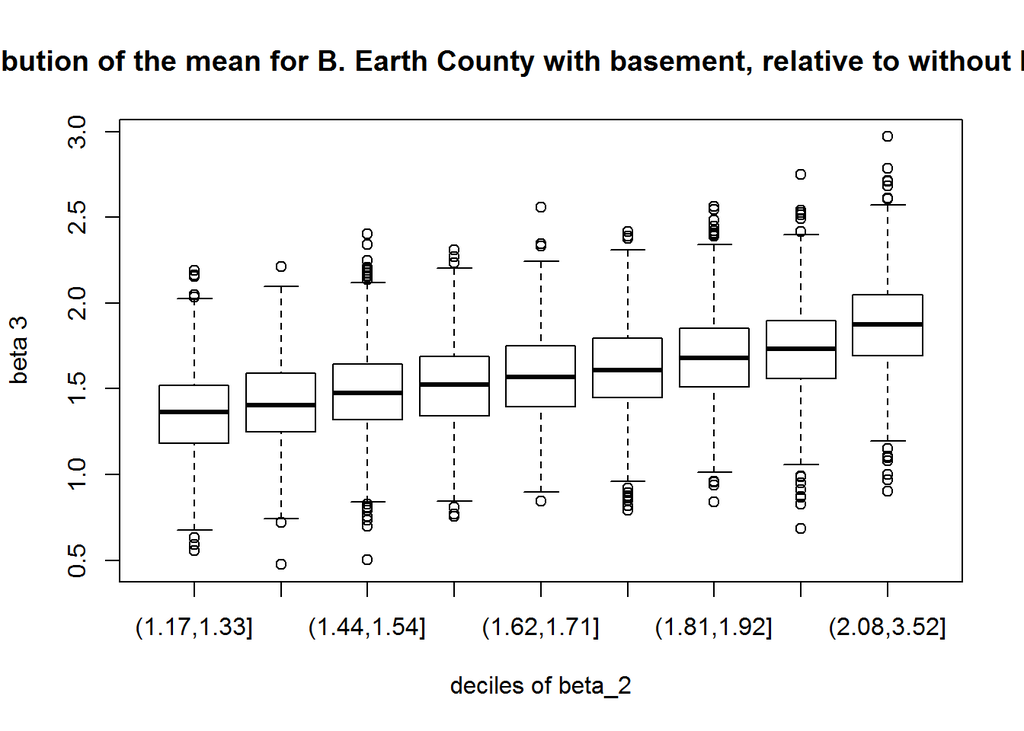

```r
s.beta.2.bins   <-  cut(s.beta[ ,2], quantile(s.beta[,2], probs=1:10/10))
boxplot(s.beta[,3]~s.beta.2.bins, xlab="deciles of beta_2", ylab="beta 3",
         main="Distribution of the mean for B. Earth County with basement, relative to without basement")
```

```r
#output <- exp (cbind (beta[,2], beta[,1]+beta[,2], beta[,3],
#beta[,1] + beta[,3], beta[,4], beta[,1] + beta[,4], beta[,1], sigma))
#for (i in 1:ncol(output)) print (round(quantile(output[,i],c(.25,.5,.75)),1))
```

As we can see, this two effects co-variate positively.

- **14b**  
  Suppose another house is sampled at random from Blue Earth County (`counties=1`). Sketch the posterior predictive distribution for its radon measurement and give a 95% predictive interval. Express the interval on the original (unlogged) scale.

A proposed answer is [here](http://www.stat.columbia.edu/~gelman/book/solutions3.pdf) but I did not write it down as I don’t fully understand it yet (and run out of time).

- **15**  
  Run a full HLM example and compare with a fixed effect regression.

A proposed answer is [here](http://ascratchpad.blogspot.com/2010/07/bayes-election-prediction-r-code-gelman.html) but I did not write it down as I don’t fully understand it yet (and run out of time).

The following code comes from this website and make reference to the original author as Dr. Surya Tokdar.

```r
setwd("C:/Users/fhocesde/Documents/tutorials/Bayesian/BDA3")
## Get Data

prez88 <- read.table("prez48to88.txt", header = T)
prez92 <- read.table("prez92.txt", header = T)

## Get y, X

y <- prez88[,1]
X <- as.matrix(prez88[, -(1:4)])
n <- nrow(X)
p <- ncol(X)

## Least square calculations

beta.ls <- lm(y ~ 0 + X)$coeff
V <- crossprod(X)
resid.ls <- y - c(X %*% beta.ls)
s2 <- sum(resid.ls^2) / (n - p)

## Xnew from 1992 data

Xnew <- as.matrix(prez92[, -(1:4)])
nnew <- nrow(Xnew)
```